# Milestone Report

Nguyen Son Linh

6/17/2020

## Synopsis

In this report, I will try to develop an understanding of the properties of the training dataset, which will help build the final prediction model. Only English is used here.

## Setup

We will load the required packages and set the necessities.

```r
library(knitr)
library(ggplot2)
library(dplyr)
library(tm)
library(RWeka)
rm(list = ls(all.names = T))
setwd("C:/Users/linhn/Documents/R/project/datasciencecapstone")
```

```r
# Blogs
blogsFileName <- "Data/final/en_US/en_US.blogs.txt"
con <- file(blogsFileName, open = "r")
blogs <- readLines(con, encoding = "UTF-8", skipNul = TRUE)
close(con)

# News
newsFileName <- "Data/final/en_US/en_US.news.txt"
con <- file(newsFileName, open = "r")
news <- readLines(con, encoding = "UTF-8", skipNul = TRUE)
close(con)

# Twitter
twitterFileName <- "Data/final/en_US/en_US.twitter.txt"
con <- file(twitterFileName, open = "r")
twitter <- readLines(con, encoding = "UTF-8", skipNul = TRUE)
close(con)
```

## Basic data summary

Before any kind of analysis, a basic summary of the files is handy.

| File | FileSize | Lines | Characters | Words | WPL.Min | WPL.Mean | WPL.Max |
| --- | --- | --- | --- | --- | --- | --- | --- |
| en_US.blogs.txt | 200 MB | 899288 | 206824505 | 37570839 | 0 | 42 | 6726 |
| en_US.news.txt | 196 MB | 77259 | 15639408 | 2651432 | 1 | 35 | 1123 |
| en_US.twitter.txt | 159 MB | 2360148 | 162096241 | 30451170 | 1 | 13 | 47 |

From the summary table, it can be observed that each text file has low number of words per lines, with Tweets understandbly the lowest due to its short nature.  
Also, all three files are extremely large, hence I will only take a 0.2% sample from each file for analysis in this report.

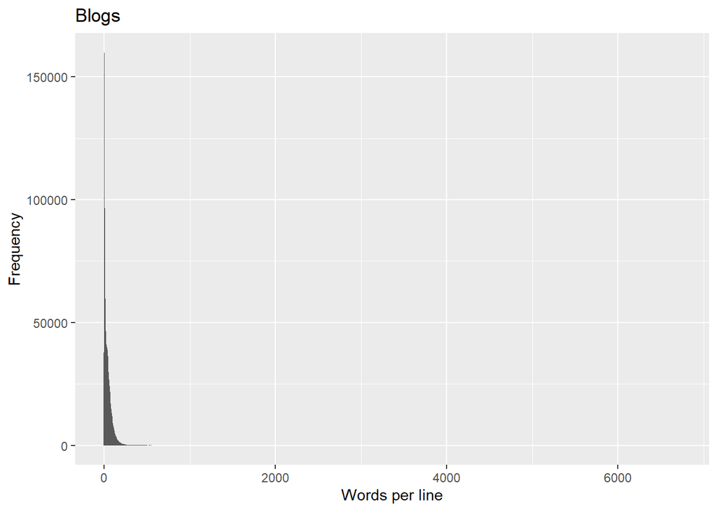

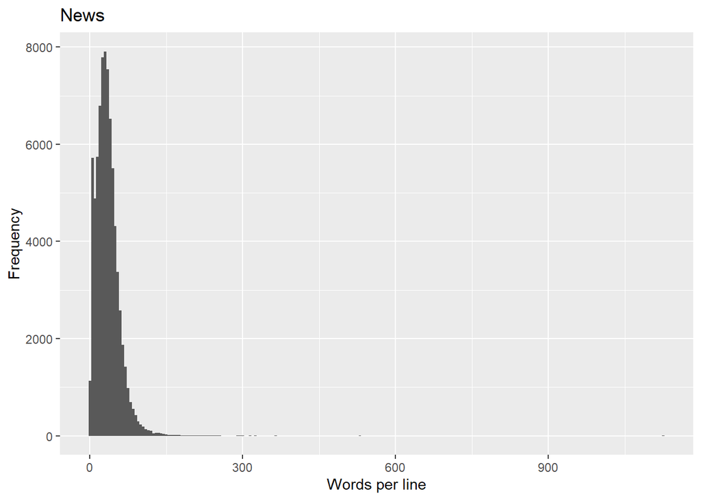

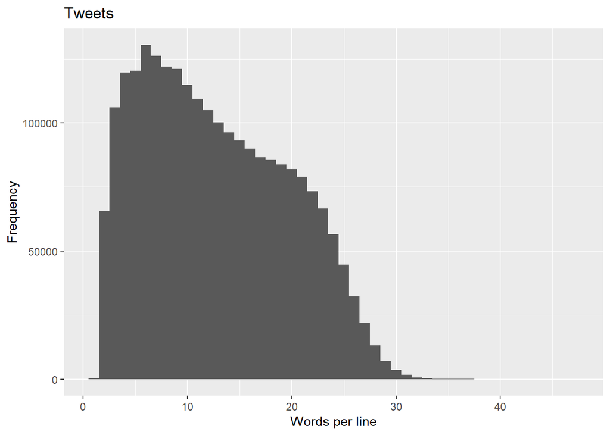

## Sampling data

Now it’s turn to prepare the sampling data. Also clean the data.

## Build corpus

After completing the above, we move on to build the corpus from the sampled data. The `tm` library will be utilised to do the following:

1. Remove URL, Twitter handle, etc. by converting them to spaces.
2. Convert all words to lowercase.
3. Remove all stopwords.
4. Remove punctuation marks, numbers, *profanity words*.
5. Cut whitespace.

For convienience, the output data will be written in the .RDS format.

Note: The profanity wordlist is obtained from [here](http://www.cs.cmu.edu/~biglou/resources/).

## Exploratory Data Analysis

After cleaning the data and build a corpus, we now do the EDA. More specifically, we will look at word frequencies and n-gram generation.

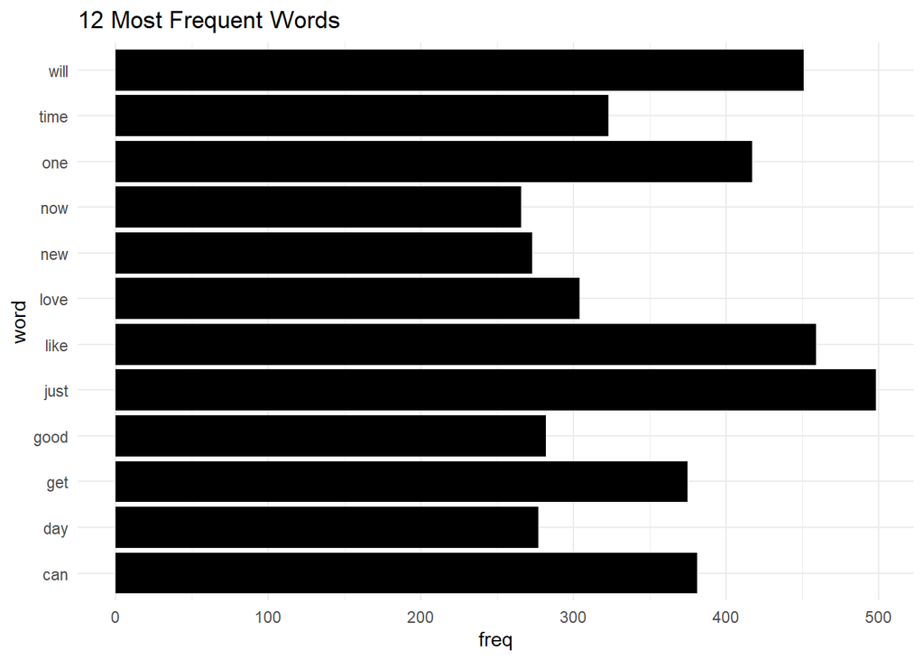

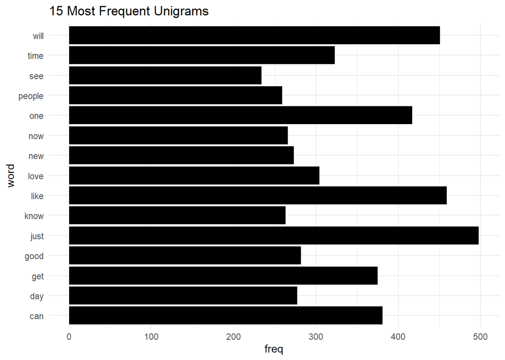

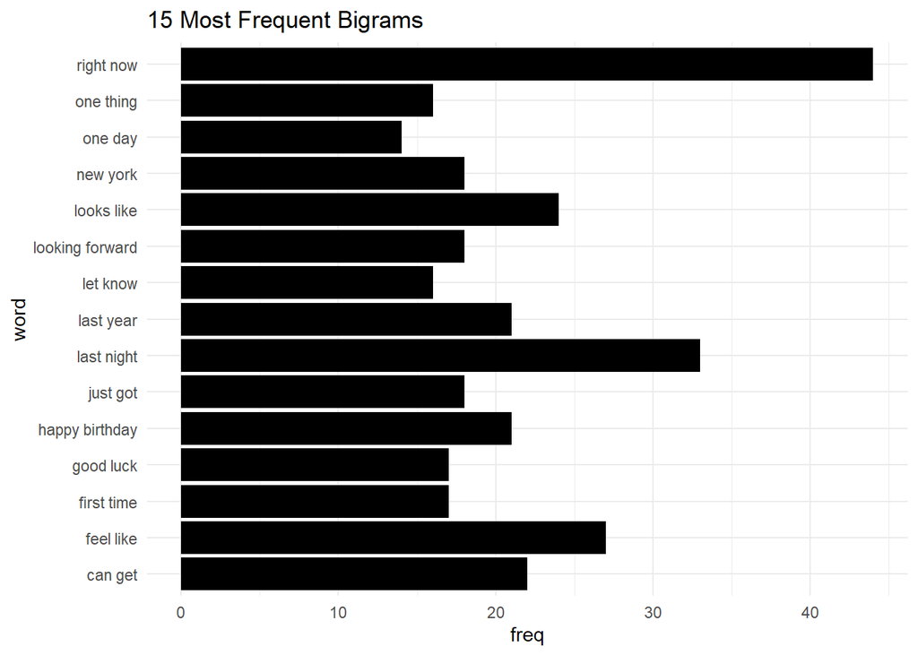

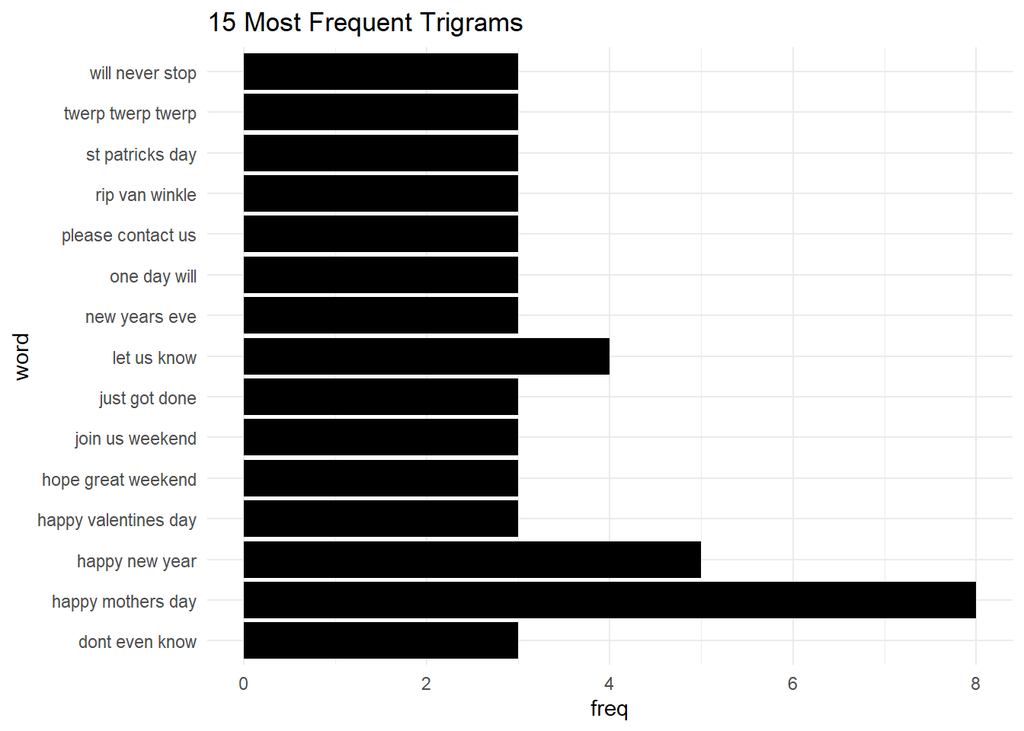

## Conclusion

Based on the analysis, it is observed that when n in n-gram increases, the frequency decrease. Hence a viable strategy would be to predict an unigram following the entered phrase. When a full term is generated, look for bigrams and trigrams down the line.

## Appendix

Attached here are the codes to produce the charts in this document.

```r
library(stringi)
file_size <- round(file.info(c(blogsFileName,
                                newsFileName,
                                twitterFileName))$size / 1024 ^ 2)
no_lines <- sapply(list(blogs, news, twitter), length)
no_char <- sapply(list(nchar(blogs), nchar(news), nchar(twitter)), sum)
no_words <- sapply(list(blogs, news, twitter), stri_stats_latex)[4,]
wpl <- lapply(list(blogs, news, twitter), function(x) stri_count_words(x))
wplSummary <- sapply(list(blogs, news, twitter),
             function(x) summary(stri_count_words(x))[c('Min.', 'Mean', 'Max.')])
rownames(wplSummary) <- c('WPL.Min', 'WPL.Mean', 'WPL.Max')
summary <- data.frame(
    File = c("en_US.blogs.txt", "en_US.news.txt", "en_US.twitter.txt"),
    FileSize = paste(file_size, " MB"),
    Lines = no_lines,
    Characters = no_char,
    Words = no_words,
    t(rbind(round(wplSummary)))
)
kable(summary,
      row.names = FALSE,
      align = c("l", rep("r", 7)),
      caption = "")
```

```r
set.seed(4031)
sample_size = 0.002

sample_blogs = sample(blogs, length(blogs) * sample_size, replace = F)
sample_news = sample(news, length(news) * sample_size, replace = F)
sample_tweets = sample(twitter, length(twitter) * sample_size, replace = F)

sample_blogs <- iconv(sample_blogs, "latin1", "ASCII", sub = "")
sample_news <- iconv(sample_news, "latin1", "ASCII", sub = "")
sample_tweets <- iconv(sample_tweets, "latin1", "ASCII", sub = "")

sample_data <- c(sample_blogs, sample_news, sample_tweets)
con <- file("data/sample.txt", open = "w")
writeLines(sample_data, con)
close(con)

sample_data_lines <- length(sample_data)

rm(blogs, news, twitter, sample_blogs, sample_news, sample_tweets)
```

```r
con <- file("Data/profanity.txt", open = "r")
profanity_words <- readLines(con, encoding = "UTF-8", skipNul = TRUE)
close(con)
profanity_words <- iconv(profanity_words, "latin1", "ASCII", sub = "")

corpusBuilder <- function(data, profanity){
  docs <- VCorpus(VectorSource(data))
  to_space <- content_transformer(function(string, pattern) gsub(pattern, " ", string))

  docs <- tm_map(docs, to_space, "(f|ht)tp(s?)://(.*)[.][a-z]+")
  docs <- tm_map(docs, to_space, "@[^\\s]+")
  docs <- tm_map(docs, to_space, "\\b[A-Z a-z 0-9._ - ]*[@](.*?)[.]{1,3} \\b")

  docs <- tm_map(docs, removeWords, profanity)
  docs <- tm_map(docs, tolower)
  docs <- tm_map(docs, removeWords, stopwords("english"))
  docs <- tm_map(docs, removePunctuation)
  docs <- tm_map(docs, removeNumbers)
  docs <- tm_map(docs, stripWhitespace)
  docs <- tm_map(docs, PlainTextDocument)
  return(docs)
}

corpus <- corpusBuilder(sample_data, profanity_words)
saveRDS(corpus, file = "Data/en_US.corpus.rds")
```

```r
tdm <- TermDocumentMatrix(corpus)
freq <- sort(rowSums(as.matrix(tdm)), decreasing = T)

freq_table <- data.frame(word = names(freq), freq = freq)

# Plot the 12 most frequent_words
freq_table <- freq_table[1:12,]
freq_table %>%
  ggplot(aes(x = word, y = freq)) +
  geom_bar(stat = "Identity", fill = "black") +
  coord_flip() +
  ggtitle("12 Most Frequent Words") +
  theme_minimal()

rm(tdm, freq, freq_table)
```

```r
unigram_tokeniser <- function(x) NGramTokenizer(x, Weka_control(min = 1, max = 1))
bigram_tokeniser <- function(x) NGramTokenizer(x, Weka_control(min = 2, max = 2))
trigram_tokeniser <- function(x) NGramTokenizer(x, Weka_control(min = 3, max = 3))
```

```r
uni_tdm <- TermDocumentMatrix(corpus, control = list(tokenize = unigram_tokeniser))
uni_freq <- sort(rowSums(as.matrix(removeSparseTerms(uni_tdm, 0.9999))), decreasing = T)
uni_freq_table <- data.frame(word = names(uni_freq), freq = uni_freq)

uni_freq_table <- uni_freq_table[1:15,]
uni_freq_table %>%
  ggplot(aes(x = word, y = freq)) +
  geom_bar(stat = "Identity", fill = "black") +
  coord_flip() +
  ggtitle("15 Most Frequent Unigrams") +
  theme_minimal()
```

```r
bi_tdm <- TermDocumentMatrix(corpus, control = list(tokenize = bigram_tokeniser))
bi_freq <- sort(rowSums(as.matrix(removeSparseTerms(bi_tdm, 0.9999))), decreasing = T)
bi_freq_table <- data.frame(word = names(bi_freq), freq = bi_freq)

bi_freq_table <- bi_freq_table[1:15,]
bi_freq_table %>%
  ggplot(aes(x = word, y = freq)) +
  geom_bar(stat = "Identity", fill = "black") +
  coord_flip() +
  ggtitle("15 Most Frequent Bigrams") +
  theme_minimal()
```

```r
tri_tdm <- TermDocumentMatrix(corpus, control = list(tokenize = trigram_tokeniser))
tri_freq <- sort(rowSums(as.matrix(removeSparseTerms(tri_tdm, 0.9999))), decreasing = T)
tri_freq_table <- data.frame(word = names(tri_freq), freq = tri_freq)

tri_freq_table <- tri_freq_table[1:15,]
tri_freq_table %>%
  ggplot(aes(x = word, y = freq)) +
  geom_bar(stat = "Identity", fill = "black") +
  coord_flip() +
  ggtitle("15 Most Frequent Trigrams") +
  theme_minimal()
```